# Multi-threaded LZ4 and ZSTD compression from R

Mark Klik

2018-01-10

The *fst* package uses LZ4 and ZSTD to compress columnar data. In the latest release, methods *compress_fst* and *decompress_fst* were added which allow for direct (multi-threaded) access to these excellent compressors.

# LZ4 and ZSTD

[LZ4](http://lz4.github.io/lz4/) is one of the fastest compressors around, and like all LZ77-type compressors, decompression is even faster. The *fst* package uses LZ4 to compress and decompress data when lower compression levels are selected (in method *write_fst*). For higher compression levels, the [ZSTD](https://github.com/facebook/zstd) compressor is used, which offers superior compression ratio’s but requires more CPU resources.

# How to use LZ4 and ZSTD from the *fst* package

From version 0.8.0, methods *compress_fst* and *decompress_fst* are available in the package. These methods give you direct access to LZ4 and ZSTD. As an example of how they can be used, we download a 90 MB file [from Kaggle](https://www.kaggle.com/stackoverflow/so-survey-2017) and recompress it using ZSTD:

```r
library(fst)

# you can download this file from https://www.kaggle.com/stackoverflow/so-survey-2017
sample_file <- "survey_results_public.csv"

# read file contents into a raw vector
raw_vec <- readBin(sample_file, "raw", file.size(sample_file))

# compress bytes with ZSTD at a compression level of 20 percent
compressed_vec <- compress_fst(raw_vec, "ZSTD", 20)

# write the compressed data into a new file
compressed_file <- "survey_results_public.fsc"
writeBin(compressed_vec, compressed_file)

# compression ratio
file.size(sample_file) / file.size(compressed_file)
```

```
## [1] 8.949609
```

using a ZSTD compression level of 20 percent, the contents of the *csv* file are compressed to about 11 percent of the original size (calculated as the inverse of the compression ratio). To decompress the generated compressed file again you can do:

```r
# read compressed file into a raw vector
compressed_vec <- readBin(compressed_file, "raw", file.size(compressed_file))

# decompress file contents
raw_vec_decompressed <- decompress_fst(compressed_vec)
```

A nice feature of *data.table*’s *fread* method is that it can parse in-memory data directly. That means that we can easily feed our raw vector to *fread*:

```r
library(data.table)

# read data set from the in-memory csv
dt <- fread(rawToChar(raw_vec_decompressed))
```

This effectively reads your *data.table* from a compressed file, which saves disk space and increases read speed for slow disks.

# Multi-threading

Methods *compress_fst* and *decompress_fst* use a fully multi-threaded implementation of the LZ4 and ZSTD algorithms. This is accomplished by dividing the data into (at maximum) 48 blocks, which are then processed in parallel. This increases the compression and decompression speeds significantly at a small cost to compression ratio:

```r
library(microbenchmark)

threads_fst(8)  # use 8 threads

# measure ZSTD compression performance at low setting
compress_time <- microbenchmark(
  compress_fst(raw_vec, "ZSTD", 10),
  times = 500
)

# decompress again
decompress_time <- microbenchmark(
  decompress_fst(compressed_vec),
  times = 500
)

cat("Compress: ", 1e3 * as.numeric(object.size(raw_vec)) / median(compress_time$time), "MB/s",
    "Decompress: ", 1e3 * as.numeric(object.size(raw_vec)) / median(decompress_time$time), "MB/s")
```

```
## Compress:  1299.649 MB/s Decompress:  1948.932 MB/s
```

That’s a ZSTD compression speed of around 1.3 GB/s!

# Bring on the cores

With more cores, you can do more parallel compression work. When we do the compression and decompression measurements above for a range of thread and compression level settings, we find the following dependency between speed and parallelism:

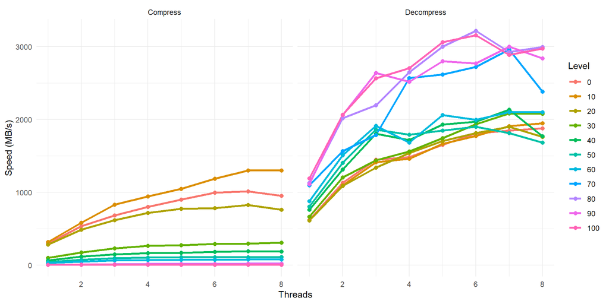

*Figure 1: Compression and decompression speeds vs the number of cores used for computation*

The code that was used to obtain these results is given in the last paragraph. As can be expected, the compression speed is highest for lower compression level settings. But interesting enough, decompression speeds actually increase with higher compression settings! For the highest levels, ZSTD decompression speeds of more than 3 GB/s were measured in our experiment!

Different compression levels settings lead to different compression ratio’s. This relation is depicted below. For completeness, LZ4 compression ratio’s were added as well:

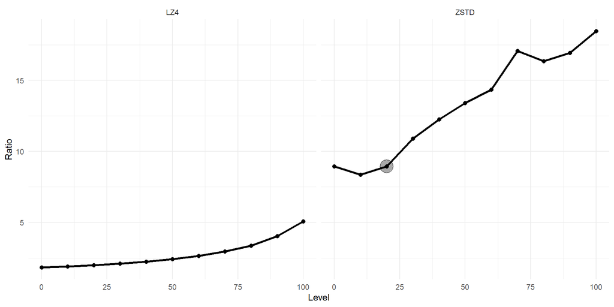

*Figure 2: Compression ratio for different settings of the compression level*

The highlighted point at a 20 percent (ZSTD) compression level corresponds to the measurement that we did earlier. It’s clear from the graph that with a combination of LZ4 and ZSTD, a wide range of compression ratio’s (and speeds) is available to the user.

# The case for high compression levels

There are many use cases where you compress your data only once but decompress it much more often. For example, you can compress and store a file that will need to be read many times in the future. In that case it’s very useful to spend the CPU resources on compressing at a higher setting. It will give you higher decompression speeds during reads and the compressed data will occupy less space.

Also, when operating from a disk that has a lower speed than the (de-)compression algorithm, compression can really help. For those cases, compression will actually increase the total transfer speed because (much) less data has to be moved to or from the disk. This is also the main reason why *fst* is able to serialize a data set at higher speeds than the physical limits of a drive.

(Please take a look at this post to get an idea of how that works exactly)

# Benchmark code

Below is the benchmark script that was used to obtain the dependency graph for the number of cores and compression level.

```r
library(data.table)

# benchmark results
bench <- data.table(Threads = as.integer(NULL), Time = as.numeric(NULL),
  Mode = as.character(NULL), Level = as.integer(NULL), Size = as.numeric(NULL))

# Note that compression time increases steadily with higher levels.
# If you want to run this code yourself, start by using levels 10 * 0:5
for (level in 10 * 0:10) {
  for (threads in 1:parallel::detectCores()) {

    cat(".")  # show some progress
    threads_fst(threads)  # set number of threads to use

    # compress measurement
    compress_time <- microbenchmark(
      compressed_vec <- compress_fst(raw_vec, "ZSTD", level), times = 25)

    # decompress measurement
    decompress_time <- microbenchmark(
      decompress_fst(compressed_vec), times = 25)

    # add measurements to the benchmark results
    bench <- rbindlist(list(bench,
      data.table(
        Threads = threads,
        Time = median(compress_time$time),
        Mode = "Compress",
        Level = level,
        Size = as.integer(object.size(compressed_vec))),
      data.table(
        Threads = threads,
        Time = median(decompress_time$time),
        Mode = "Decompress",
        Level = level,
        Size = as.integer(object.size(compressed_vec)))))
  }
}
```

This creates a *data.table* with compression and decompression benchmark results.

> *This post is also available on [R-bloggers](https://www.r-bloggers.com/)*